# Analiza wydatków na swieze owoce we Wloszech

Karina Waligora i Paulina Korzeniowska

27 01 2021

# **Wstep**

Nasz projekt przygotowalysmy w oparciu o dane obejmujace dane jednostkowe badania budzetu gospodarstw domowych we Wloszech w 2011 roku. Wybralysmy interesujace nas dane zwiazane z analiza wydatkow na swieze owoce przez Wlochow. Chcemy przeanalizowac czynniki jakie maja wplyw na wydatki na poszczegolne rodzaje owocow i w tym celu bedziemy wykonywac odpowiednie badania i prezentacje graficzne danych.

Chcemy skupic sie na zgadanieniach takich jak:

1. Czy możemy okreslic, w których miesiacach ankietowane osobyly wydawaly najwiecej pieniedzy na owoce cytrusowe?
2. Czy możemy okreslic, w których regionach ankietowane osobyly wydawaly najwiecej pieniedzy na owoce?
3. Czy możemy stwierdzic że kobiety i meżczyzni kupuja praktycznie taka sama ilosc owoców cytrusowych?
4. Jak plasuja sie wartosci wydatkow za jablka
5. Czy możemy stwierdzic, w ktorym miesiacu wydatki na owoce z pestka byly najwieksze

# **Obrobka danych**

## Nadajemy nazwy odpowiednim obiektom

```r
owoce <- select(dane,Mese,Regione,TIPFAM,NC,Eta4_1, Sesso1,C_1601,C_1602,C_1603,C_1604,C_1605,C_1606,C_1607, owoce_cytrusowe = C_1601, Banany=C_1602, Jablka=C_1603, Gruszki=C_1604, Owoce_z_pestka=C_1605, Winogronatrusk=C_1606, inne=C_1607, miesiac=Mese, Region = Regione, typ_rodziny= TIPFAM, liczbaos=NC, Wiek = Eta4_1, Plec = Sesso1)
```

### Usuniecie pustych danych

```r
colSums(is.na(owoce))
```

```
##         miesiac          Region     typ_rodziny        liczbaos            Wiek
##               0               0               0               0               0
##            Plec owoce_cytrusowe          Banany          Jablka         Gruszki
##             226               0               0               0               0
##  Owoce_z_pestka  Winogronatrusk            inne
##               0               0               0
```

```r
owoce <- na.omit(owoce)
```

### Dodanie kolumny z suma wydatkow na owoce

```r
owoce <- owoce %>%
  mutate(owoce, Wydatki_owoce = owoce_cytrusowe + Banany + Jablka + Gruszki + Owoce_z_pestka + Winogronatrusk + inne)
```

# Interpretacja danych:

- owoce_cytrusowe - wydatki na owoce cytrusowe
- Banany - wydatki na banany
- Jablka - wydatki na jablka
- Gruszki - wydatki na gruszki
- Owoce_z_pestka - wydatki na owoce z pestka
- Winogronatrusk - wydatki na winogrona i truskawki
- inne - wydatki na inne swieze owoce
- miesiac - miesiac badania
- Region - region zamieszkania
- typ_rodziny - typ rodziny
- liczbaos - liczba osob w gospodaarstwie domowym
- Wiek - wiek osobyly ankietowanej
- Plec - plec osobyly ankietowanej

## Dotychczasowa prezentacja danych

| miesiac | Region | typ_rodziny | liczbaos | Wiek | Plec | owoce_cytrusowe | Banany | Jablka | Gruszki | Owoce_z_pestka | Winogronatrusk | inne | Wydatki_owoce |
| --- | --- | --- | --- | --- | --- | --- | --- | --- | --- | --- | --- | --- | --- |
| 7 | 7 | 1 | 1 | 3 | 1 | 0.00 | 0.00 | 0 | 0.00 | 10.94 | 0.00 | 0 | 10.94 |
| 11 | 3 | 10 | 4 | 3 | 2 | 9.41 | 7.94 | 0 | 0.00 | 0.00 | 0.00 | 0 | 17.35 |
| 7 | 7 | 7 | 3 | 3 | 1 | 0.00 | 11.46 | 0 | 0.00 | 14.08 | 0.00 | 0 | 25.54 |
| 9 | 15 | 4 | 2 | 3 | 1 | 5.30 | 5.42 | 0 | 5.93 | 0.00 | 0.00 | 0 | 16.65 |
| 3 | 10 | 10 | 2 | 2 | 2 | 7.85 | 12.95 | 0 | 16.06 | 0.00 | 24.14 | 14 | 75.00 |

## Usuwanie danych ostajacych

### Histogramy

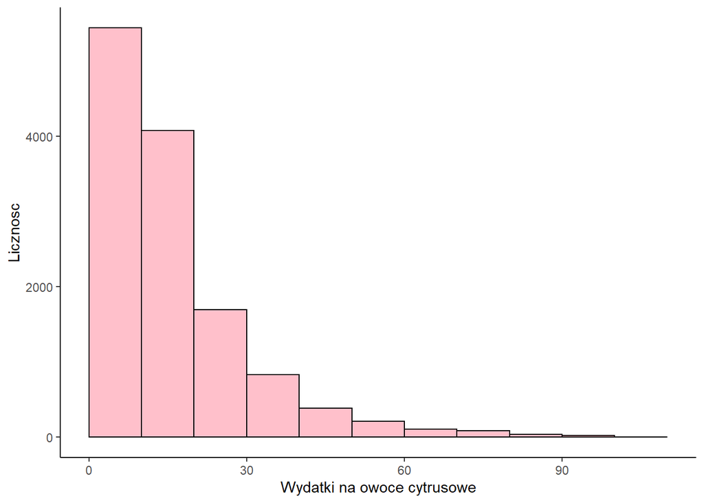

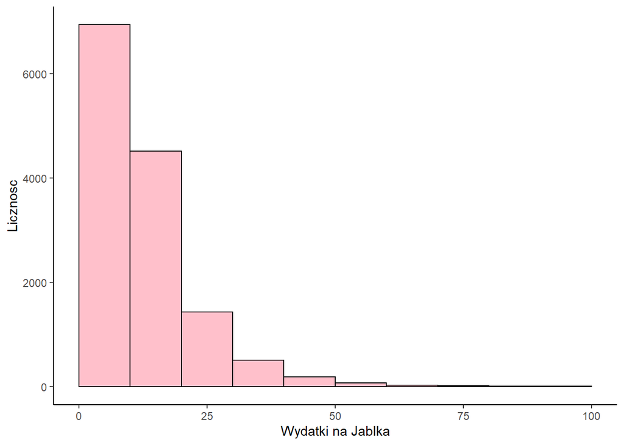

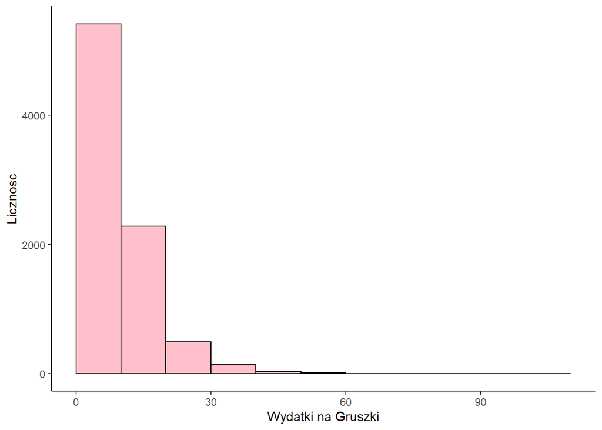

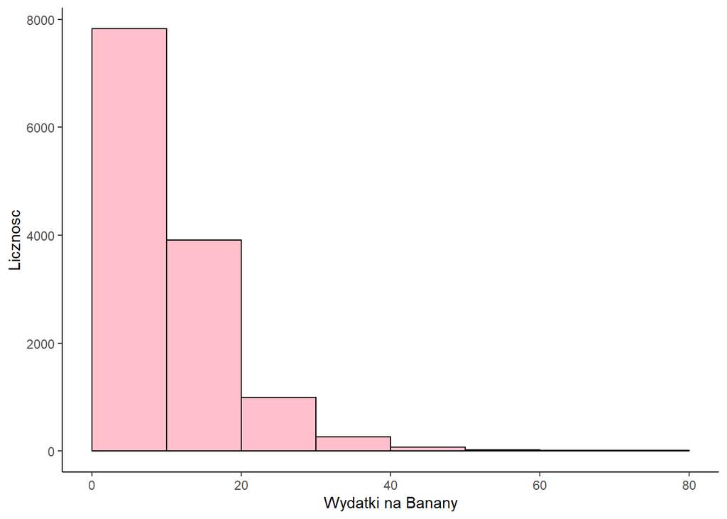

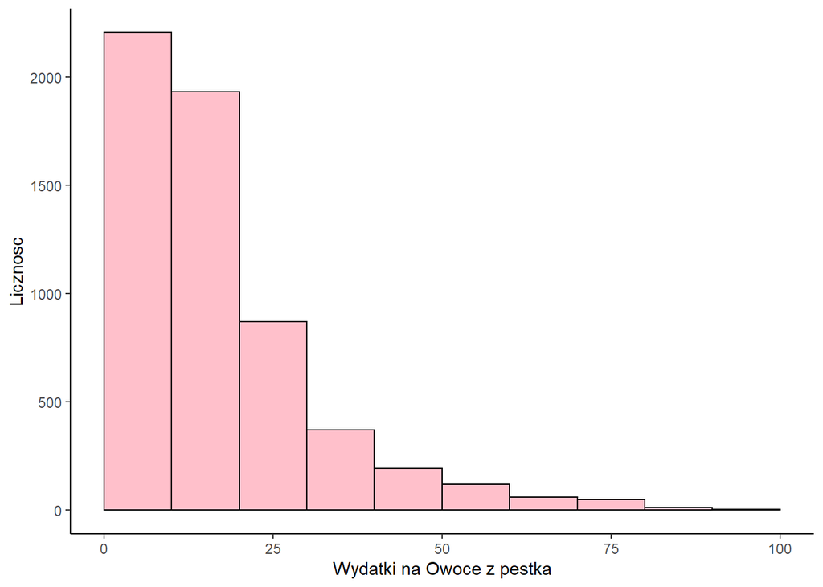

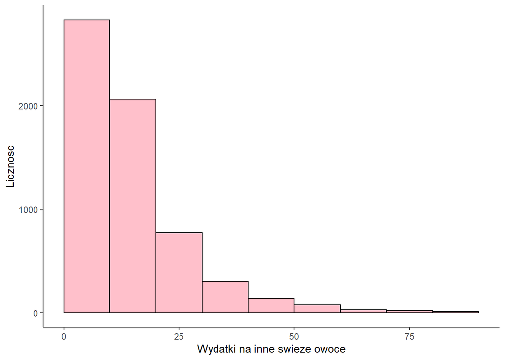

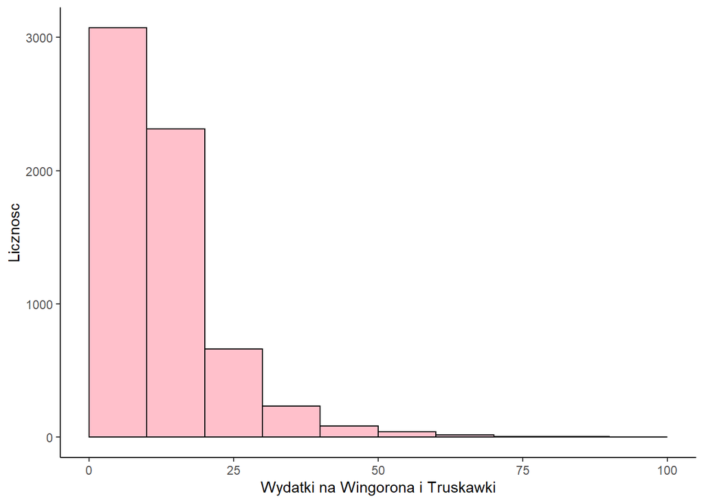

## Usuwanie danych odstajacych

**Ograniczam dane bazujac na histogramach**

```r
owocef <- owoce %>%
  filter(owoce_cytrusowe < 90 ,
         Jablka <65 ,
         Banany <60,
         Gruszki < 50 ,
         Owoce_z_pestka < 90,
         Winogronatrusk <75,
         inne < 90,
          )
```

## Przeksztalcanie danych Region, Miesiac, Plec,Wiek, typ_rodziny

*Ostateczne dane*

| miesiac | Region | typ_rodziny | liczbaos | Wiek | Plec | owoce_cytrusowe | Banany | Jablka | Gruszki | Owoce_z_pestka | Winogronatrusk | inne | Wydatki_owoce |
| --- | --- | --- | --- | --- | --- | --- | --- | --- | --- | --- | --- | --- | --- |
| lipiec | polnoc | samotna | 1 | dorosla | M | 0.00 | 0.00 | 0.00 | 0.00 | 10.94 | 0.00 | 0 | 10.94 |
| listopad | polnoc | samotny_rodzic | 4 | dorosla | K | 9.41 | 7.94 | 0.00 | 0.00 | 0.00 | 0.00 | 0 | 17.35 |
| lipiec | polnoc | para_z_dziecmi | 3 | dorosla | M | 0.00 | 11.46 | 0.00 | 0.00 | 14.08 | 0.00 | 0 | 25.54 |
| wrzesien | poludnie | para_bez_dzieci | 2 | dorosla | M | 5.30 | 5.42 | 0.00 | 5.93 | 0.00 | 0.00 | 0 | 16.65 |
| marzec | centrum | samotny_rodzic | 2 | mloda_dorosla | K | 7.85 | 12.95 | 0.00 | 16.06 | 0.00 | 24.14 | 14 | 75.00 |
| czerwiec | poludnie | para_z_dziecmi | 3 | dorosla | M | 11.07 | 9.36 | 4.86 | 0.00 | 0.00 | 6.72 | 0 | 32.01 |
| styczen | centrum | samotny_rodzic | 2 | mloda_dorosla | K | 5.88 | 4.22 | 0.00 | 0.00 | 0.00 | 0.00 | 0 | 10.10 |
| czerwiec | centrum | samotny_rodzic | 2 | starsza | K | 18.21 | 20.96 | 20.57 | 0.00 | 0.00 | 0.00 | 0 | 59.74 |
| marzec | polnoc | samotna | 1 | dorosla | M | 53.35 | 0.00 | 0.00 | 0.00 | 0.00 | 0.00 | 0 | 53.35 |
| wrzesien | polnoc | para_z_dziecmi | 4 | dorosla | M | 0.00 | 10.84 | 14.04 | 6.58 | 0.00 | 0.00 | 0 | 31.46 |

*ostateczna baza danych, na ktorej bedziemy pracowac - owocef*

# **Analiza**

**Statystyki opisowe zmiennych ilosciowych**

```
##  owoce_cytrusowe      Banany           Jablka         Gruszki
##  Min.   : 0.000   Min.   : 0.000   Min.   : 0.00   Min.   : 0.000
##  1st Qu.: 0.000   1st Qu.: 0.000   1st Qu.: 0.00   1st Qu.: 0.000
##  Median : 4.360   Median : 4.210   Median : 5.61   Median : 0.000
##  Mean   : 9.062   Mean   : 6.048   Mean   : 7.60   Mean   : 3.551
##  3rd Qu.:13.490   3rd Qu.: 9.250   3rd Qu.:11.41   3rd Qu.: 6.070
##  Max.   :89.270   Max.   :59.990   Max.   :64.71   Max.   :49.900
##  Owoce_z_pestka   Winogronatrusk        inne        Wydatki_owoce
##  Min.   : 0.000   Min.   : 0.000   Min.   : 0.000   Min.   :  0.00
##  1st Qu.: 0.000   1st Qu.: 0.000   1st Qu.: 0.000   1st Qu.: 16.74
##  Median : 0.000   Median : 0.000   Median : 0.000   Median : 30.95
##  Mean   : 4.308   Mean   : 3.595   Mean   : 3.957   Mean   : 38.12
##  3rd Qu.: 2.980   3rd Qu.: 4.870   3rd Qu.: 4.340   3rd Qu.: 52.01
##  Max.   :89.960   Max.   :73.970   Max.   :88.210   Max.   :365.68
```

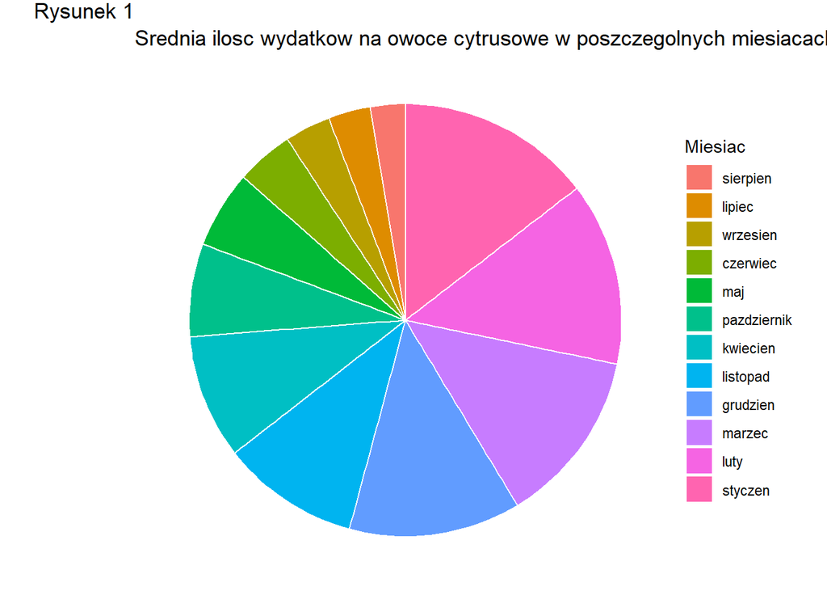

**Wnioski:** Na tej podstawie mozemy stwerdzic, ze srednia ilosc wydatkow na owoce cytrusowe bylyla najwieksza w styczniu, lutym, marcu i grudniu a najmniejsza w sierpniu, lipcu i wrzesniu.

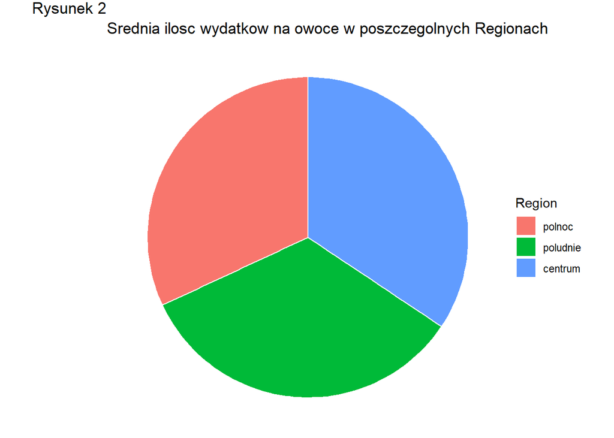

**Wnioski:** Na tej podstawie możemy stwerdzic, że srednia ilosc wydatkow na owoce byla podobna w każdym Regionie

**Ile srednio kobiety i miezczyzni zakupili owocow cytrusowych?**

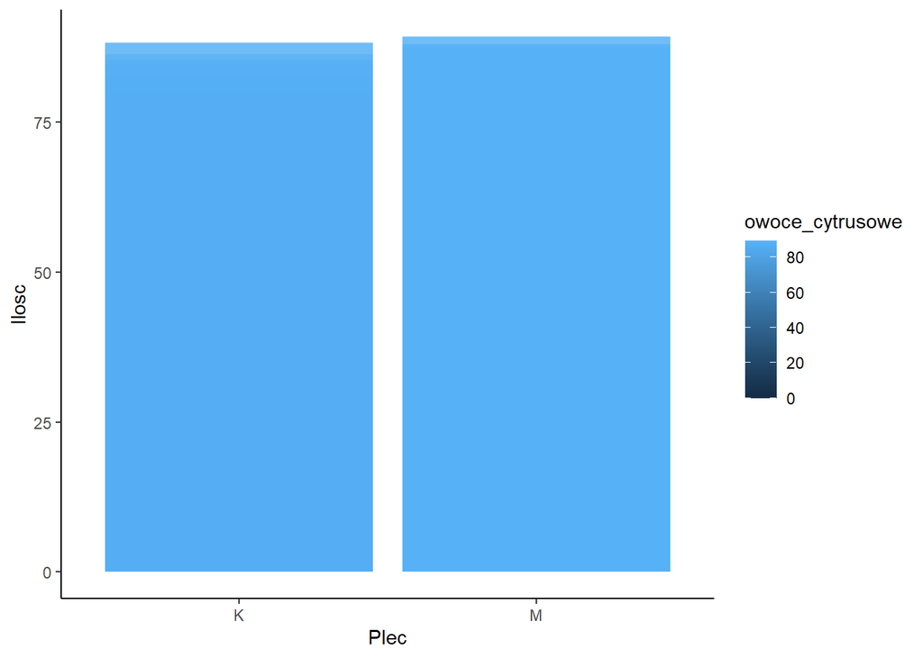

```r
owocef %>%
  group_by(Plec, owoce_cytrusowe) %>%
  summarise(Ilosc = mean(owoce_cytrusowe)) %>%
  ggplot() +
  geom_col(aes(Plec, Ilosc, fill=owoce_cytrusowe), alpha = 0.6, position = position_dodge(width=0.2)) +
  theme_classic()
```

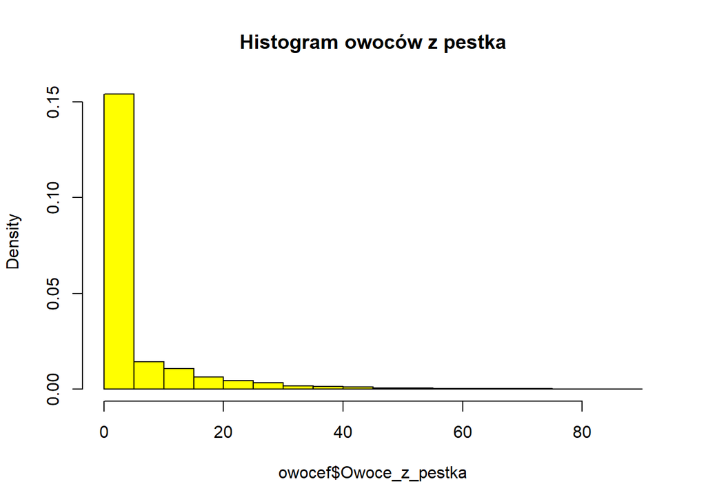

**Jak plasuja sie wartosci wydatkow za jablka?**

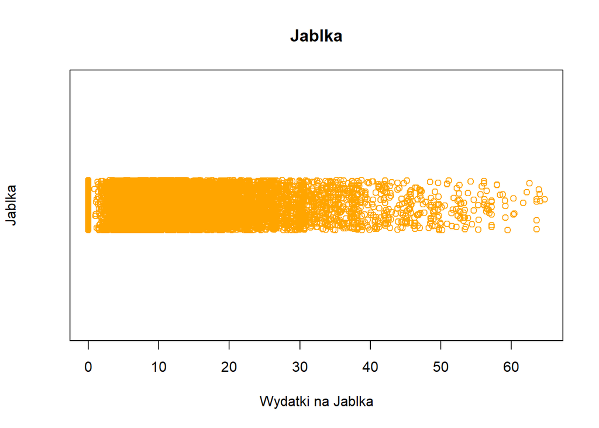

**Wnioski:** Na tej podstawie mozemy stwerdzic, ze w najwiekszej czesci wydatki za jablka mieszcza sie w przedziale od 0 do 30.

## Czy możemy stwierdzic, w ktorym miesiacu wydatki na owoze z pestka byly najwieksze?

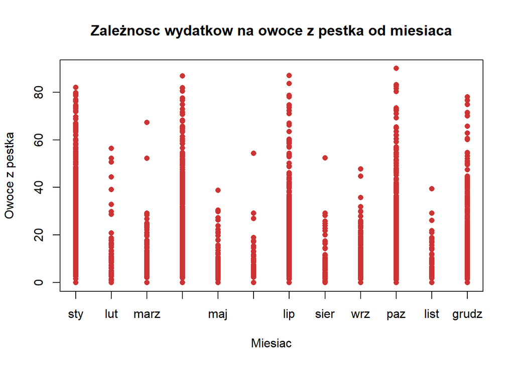

**Wnioski:** Na tej podstawie mozemy stwerdzic, ze wydtaki na owoce z pestka byly najjwieksze w styczniu, kaiwtniu, lipcu, pazdzierniku oraz grudniu.

## Regresja

```
##
## Call:
## glm(formula = owocef$Wydatki_owoce ~ owocef$typ_rodziny + owocef$Plec +
##     owocef$Region, family = "binomial", data = owocef)
##
## Deviance Residuals:
##     Min       1Q   Median       3Q      Max
## -2.7471   0.2514   0.3256   0.3801   0.5151
##
## Coefficients:
##                                  Estimate Std. Error z value Pr(>|z|)
## (Intercept)                       3.25492    0.10617  30.657  < 2e-16 ***
## owocef$typ_rodzinypara_z_dziecmi  0.02110    0.08357   0.253  0.80065
## owocef$typ_rodzinysamotna        -0.63892    0.08595  -7.433 1.06e-13 ***
## owocef$typ_rodzinysamotny_rodzic -0.29007    0.10755  -2.697  0.00699 **
## owocef$PlecM                     -0.17928    0.06956  -2.577  0.00996 **
## owocef$Regionpolnoc              -0.48398    0.07068  -6.847 7.53e-12 ***
## owocef$Regionpoludnie             0.47417    0.09084   5.220 1.79e-07 ***
## ---
## Signif. codes:  0 '***' 0.001 '**' 0.01 '*' 0.05 '.' 0.1 ' ' 1
##
## (Dispersion parameter for binomial family taken to be 1)
##
##     Null deviance: 10372  on 22712  degrees of freedom
## Residual deviance: 10071  on 22706  degrees of freedom
## AIC: 10085
##
## Number of Fisher Scoring iterations: 6
```